# Unstructure_FinalProject

Samuel Condori

2024-03-01

## Poem Analysis

Introduction: Last week, I had the pleasure of watching “Dead Poets Society,” a film that delves into the lives of students at an elite boarding school and their inspiring English teacher, Mr. Keating, who introduces them to the liberating philosophy of “Carpe Diem.” This Latin phrase, which translates to “seize the day,” struck a chord with me, urging me to contemplate its profound implications in our daily lives. This powerful message from “Dead Poets Society” has since resonated with me, igniting a desire to explore the depths of Carpe Diem and explore its topics in poetry.

Rationale: This project was inspired by the movie “Dead Poets Society,” which made me really think about the idea of “Carpe Diem” or making the most of today. I want to look at poems that talk about living life to the fullest, using tools to see which poems show this idea the strongest and what common themes they have.

Methodology:

I will use the poems tagged under Carpe Diem from poets.org, a website that offers a vast collection of poems from different eras and styles. I will scrape the website to gather a list of poems that fall under the Carpe Diem theme and then analyze them using sentiment analysis and topic modeling to understand the common themes and sentiments expressed in these poems.

```r
# Load the required libraries
library(rvest)
library(dplyr)
library(stringr)

# Read main url
url <-  "https://poets.org/poems?field_occasion_target_id=All&field_poem_themes_target_id=926&field_form_target_id=All&combine="

# Read the all the pages
page_links <- read_html(url) %>%
  html_elements("a") %>%
  html_attr("href") %>%
  grep("\\?field_occasion_target_id", ., value = TRUE) %>%
  paste0("https://poets.org/poems", .)

# The results do not show all the links available since they are visually hidden, so since i know the last page is 6 , i will add the remaining manually
base_url <- "https://poets.org/poems?field_occasion_target_id=All&field_poem_themes_target_id=926&field_form_target_id=All&combine=&page="
page_number <- 0:6
page_links <- paste0(base_url, page_number)
head(page_links)
```

```
## [1] "https://poets.org/poems?field_occasion_target_id=All&field_poem_themes_target_id=926&field_form_target_id=All&combine=&page=0"
## [2] "https://poets.org/poems?field_occasion_target_id=All&field_poem_themes_target_id=926&field_form_target_id=All&combine=&page=1"
## [3] "https://poets.org/poems?field_occasion_target_id=All&field_poem_themes_target_id=926&field_form_target_id=All&combine=&page=2"
## [4] "https://poets.org/poems?field_occasion_target_id=All&field_poem_themes_target_id=926&field_form_target_id=All&combine=&page=3"
## [5] "https://poets.org/poems?field_occasion_target_id=All&field_poem_themes_target_id=926&field_form_target_id=All&combine=&page=4"
## [6] "https://poets.org/poems?field_occasion_target_id=All&field_poem_themes_target_id=926&field_form_target_id=All&combine=&page=5"
```

```r
# With the links for each page ,now i will extract the link for every poem using a for loop
poem_links <- c()
for (i in 1:length(page_links)){
  page <- read_html(page_links[i])
  poem_links <- c(poem_links, page %>%
                    html_elements("a") %>%
                    html_attr("href") %>%
                    grep("/poem/", ., value = TRUE) %>%
                    paste0("https://poets.org", .))
}

head(poem_links)
```

```
## [1] "https://poets.org/poem/virgins-make-much-time"
## [2] "https://poets.org/poem/dreams"
## [3] "https://poets.org/poem/road-not-taken"
## [4] "https://poets.org/poem/life-fine"
## [5] "https://poets.org/poem/you-it-act-ii-scene-vii-all-worlds-stage"
## [6] "https://poets.org/poem/archaic-torso-apollo"
```

```r
# Now that we have all the links, we can start scraping the data with a function
# Function to scrape the data
scrape_poem <- function(url){
  title <- read_html(url) %>%
            html_elements(".field--title") %>%
            html_text() %>%
            .[1]
  content <- read_html(url) %>%
            html_elements(".field.field--body")
  # The text extracted has the author info in the second row,
  content_without_author <-  content[-2]
  content_unified <-html_text(content_without_author) %>%
            paste(collapse = "\n.\n")
  poem_df <- data.frame(
    Title = title,
    Content = content_unified,
    stringsAsFactors = FALSE  # Avoid converting strings to factors
  )
  return(poem_df)
}

# Scrape the data
poem_data <- lapply(poem_links, scrape_poem)
# Bind all the poems together
poem_data <- do.call(rbind, poem_data)

head(poem_data)
```

```
##                                                         Title
## 1                        To the Virgins, to Make Much of Time
## 2                                                      Dreams
## 3                                          The Road Not Taken
## 4                                                Life is Fine
## 5 As You Like It, Act II, Scene VII [All the world's a stage]
## 6                                     Archaic Torso of Apollo
##                                                                                                                                                                                                                                                                                                          …
## 1                                                                                                                                                                                                                                                                                                        …
## 2                                                                                                                                                                                                                                                                                                        …
## 3 Two roads diverged in a yellow wood,And sorry I could not travel bothAnd be one traveler, long I stoodAnd looked down one as far as I couldTo where it bent in the undergrowth;\nThen took the other, as just as fair,And having perhaps the better claim,Because it was grassy and wanted wear;Though …
## 4                                                                                                                                                                                                                                                                                                        …
## 5                                                                                                                                                                                                                       Jaques to Duke Senior\n                                             All the world…
## 6                                                                                                                                                                                                                                                                                                        …
```

## Test Cleaning

```r
library(tm)
# Cleaning for Smart Sentiment Analysis
poem_data$Content <- poem_data$Content %>%
  str_replace_all(., "\n", ".") %>%
  str_squish() %>%
  gsub("([a-z])([A-Z])", "\\1.\\2", .)%>%
  gsub("[.](\\s*[.])+", ".",.)

# Cleaning for Topic Modeling
poem_data$Content_model <- poem_data$Content %>%
  textclean::replace_contraction() %>%
  str_replace_all(., "(\\[.*?\\])", "") %>%
  gsub("([a-z])([A-Z])", "\\1 \\2", .) %>%
  tolower() %>%
  textstem::lemmatize_strings(.) %>%
  removeWords(stopwords("SMART"))
```

## Sentiment Analysis

#Smart Sentiment Analysis

```r
library(sentimentr)
library(lexicon)
function_sentiment <- function(x) {
  sentences <- get_sentences(tolower(x))
  score <- sentiment(sentences, polarity_dt = lexicon::hash_sentiment_jockers_rinker)
  meanscore <- mean(score$sentiment)
  return(meanscore)
}

poem_data$Smart_sent_score <- sapply(poem_data$Content, function_sentiment)



# Top 5 more positive poems
best_smart_poem <- poem_data %>%
  arrange(desc(Smart_sent_score)) %>%
  head(1)

best_smart_poem$Content
```

```
## [1] "Then let not Winter's ragged hand deface,In thee thy summer, ere thou be distill'd:Make sweet some vial; treasure thou some place.With beauty's treasure ere it be self-kill'd.That use is not forbidden usury,Which happies those that pay the willing loan;That's for thyself to breed another the…
```

The poem with the highest score based on the Smart Sentiment Analysis is Sonnet 6 by William Shakespeare.

```r
write.csv(poem_data, file = "C:/Users/samal/OneDrive/Desktop/Unst_project.csv", row.names = FALSE)
```

## Model Based Sentiment

```python
import nltk
from nltk.sentiment.vader import SentimentIntensityAnalyzer
import pandas as pd
import pyarrow

poem_df = pd.read_csv("C:/Users/samal/OneDrive/Desktop/Unst_project.csv")

sid = SentimentIntensityAnalyzer()

poem_df['Model_Based_scores'] = poem_df['Content'].apply(lambda lyrics: sid.polarity_scores(lyrics))

poem_df['Model_Based_scores'].iloc[0]
```

```
## {'neg': 0.089, 'neu': 0.803, 'pos': 0.107, 'compound': 0.6458}
```

```python
poem_df[['neg', 'neu', 'pos', 'compound']] = pd.DataFrame(poem_df.Model_Based_scores.tolist(), index = poem_df.index)

poem_df.head()
```

```
##                                                Title  ... compound
## 0               To the Virgins, to Make Much of Time  ...   0.6458
## 1                                             Dreams  ...   0.2023
## 2                                 The Road Not Taken  ...   0.8423
## 3                                       Life is Fine  ...  -0.9783
## 4  As You Like It, Act II, Scene VII [All the wor...  ...   0.9729
##
## [5 rows x 9 columns]
```

```python
poem_df.to_csv("C:/Users/samal/OneDrive/Desktop/new_poem_df.csv")
```

## Topic Modeling

```r
library(dplyr)
library(quanteda)
library(stringr)
library(stm)
```

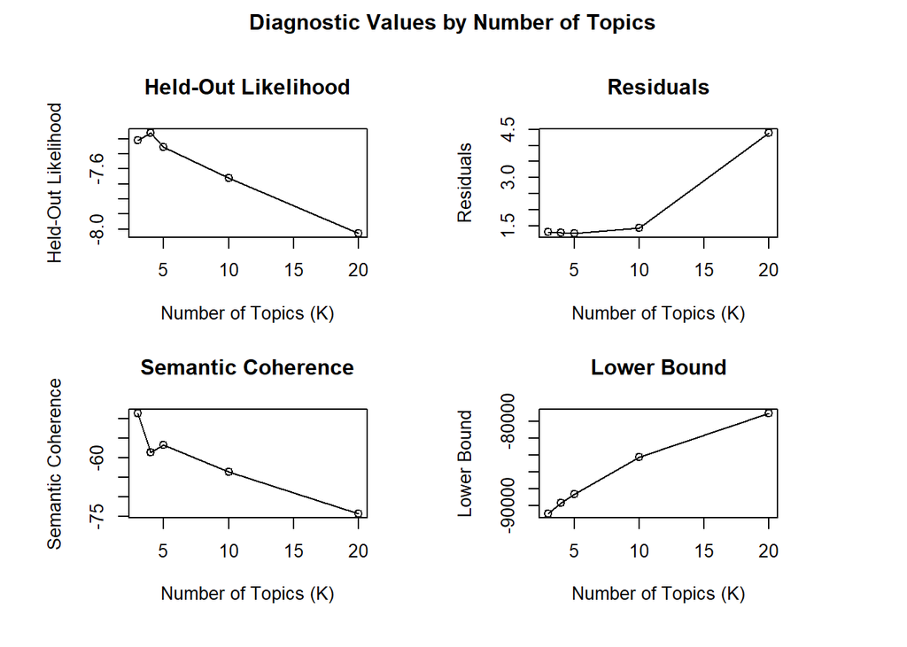

```r
# Read previous data from python
new_poem_df <- read.csv("C:/Users/samal/OneDrive/Desktop/new_poem_df.csv")


# Create a corpus and a document-feature matrix
comment_corpus <- corpus(new_poem_df, text_field = "Content_model")

comment_token <- tokens(comment_corpus,
                      remove_punct = TRUE,
                      remove_symbols = TRUE,
                      remove_numbers = TRUE)

comment_dfm <- dfm(comment_token)

comment_dfm <- dfm_trim(comment_dfm, sparsity = 0.990)

comment_stm <- convert(comment_dfm, to = "stm")

# Save the previous results to apply in the Topic Prep
docs_stm <- comment_stm$documents

vocab_stm <- comment_stm$vocab

meta_stm <- comment_stm$meta

CommentPrep <- prepDocuments(documents = docs_stm,
                           vocab = vocab_stm,
                           meta = meta_stm)

kTest <- searchK(documents = CommentPrep$documents,
             vocab = CommentPrep$vocab,
             K = c(3, 4, 5, 10, 20), verbose = FALSE)
plot(kTest)
```

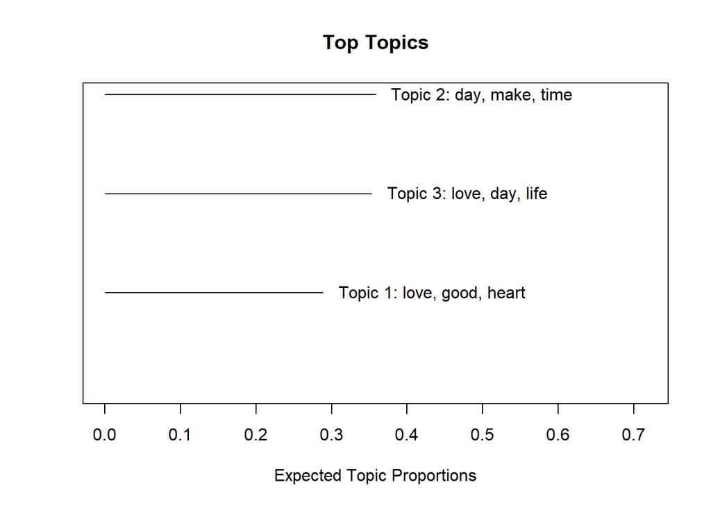

```r
# I chose 3 topics since it gives a good balance between high semantic coherence and low residuals


topics3 <- stm(documents = CommentPrep$documents,
             vocab = CommentPrep$vocab, seed = 1001,
             K = 3, verbose = FALSE)

plot(topics3)
```

The topics about Day, make and time are the most common topics across the poems.

```r
labelTopics(topics3)
```

```
## Topic 1 Top Words:
##       Highest Prob: love, good, heart, day, night, make, praise
##       FREX: difficult, spirit, praise, return, abase, captain, lilac
##       Lift: abase, adoration, breathless, captain, choice, creed, custom
##       Score: woo, praise, abase, captain, lilac, difficult, chalk
## Topic 2 Top Words:
##       Highest Prob: day, make, time, good, life, thing, live
##       FREX: color, car, pastoral, pocket, dress, frighten, sidewalk
##       Lift: absent, alley, america, bach, bench, blank, button
##       Score: spine, pastoral, car, pocket, read, exile, frighten
## Topic 3 Top Words:
##       Highest Prob: love, day, life, thou, man, time, night
##       FREX: gonna, sway, mighty, thy, thou, delight, ere
##       Lift: barren, brow, charm, cheat, common, crime, deal
##       Score: gonna, thou, portion, thy, rose, lazy, fade
```

```r
thoughts <- findThoughts(topics3, texts = CommentPrep$meta$Content, topics = 2, n = 1)
thoughts
```

```
##
##  Topic 2:
##       The translucent claws of newborn mice.this pearl cast of color,.the barely perceptible.like a ghosted threshold of being:.here not here.The single breath we hold.on the thinnest verge of sight:.not there there.A curve nearly naked .an arc of almost, .a wisp of becoming.a wand—.tiny enough t…
```

## Conclusion

Based on the results of the sentiment analysis of Carpe Diem-themed poems, it’s evident that the essence of seizing the day is encapsulated by Shalespeare’s Sonnet 6 according to its highest sentiment score. The recurring use of words such as “day,” “make,” “time,” and “life” across these poems highlights a shared use of words that poets use to express the urgency and beauty of living in the moment. This analysis shows the common threads that bind these poetic works, offering a deeper understanding of how the joy of the present is celebrated across different eras and writing styles.